```python
from bs4 import BeautifulSoup
from alternate_advanced_caching import Cache
import statsmodels.api as sm
import requests
import json
import time
import sklearn
import pandas
import matplotlib
%matplotlib inline
import matplotlib.pyplot as plt
import seaborn as sns
import numpy as np
import pandas as pd
from pandas import DataFrame
from sklearn import linear_model
```

```python
class Car():
    def __init__(self, make, model, year, price, mileage):
        #exColor is exterior color, inColor is interior color
        self.make = make
        self.model = model
        self.year = year
        self.price = price
        self.mileage = mileage


    def __str__(self):
        return ("This car is a {} {} {} with {} miles on it. Price is: {}"
        .format(self.year, self.make, self.model, self.mileage, self.price).strip("\n\r"))


#scraping from cargurus.com
def create_id(site, topic, webUrl):
    return "{}_{}_{}.json".format(site, topic, webUrl)
```

```python
import requests
import json
from datetime import datetime

DATETIME_FORMAT = "%Y-%m-%d %H:%M:%S.%f"
DEBUG = True

class Cache:
    def __init__(self, filename):
        """Load cache from disk, if present"""
        self.filename = filename
        try:
            with open(self.filename, 'r') as cache_file:
                cache_json = cache_file.read()
                self.cache_diction = json.loads(cache_json)
        except:
            self.cache_diction = {}

    def _save_to_disk(self):
        """Save cache to disk"""
        with open(self.filename, 'w') as cache_file:
            cache_json = json.dumps(self.cache_diction)
            cache_file.write(cache_json)

    def _has_entry_expired(self, timestamp_str, expire_in_days):
        """Check if cache timestamp is over expire_in_days old"""

        # gives current datetime
        now = datetime.now()

        # datetime.strptime converts a formatted string into datetime object
        cache_timestamp = datetime.strptime(timestamp_str, DATETIME_FORMAT)

        # subtracting two datetime objects gives you a timedelta object
        delta = now - cache_timestamp
        delta_in_days = delta.days


        # now that we have days as integers, we can just use comparison
        # and decide if cache has expired or not
        ##if delta_in_days > expire_in_days:
            ##return True # It's been longer than expiry time
        ##else:
        return False

    def get(self, identifier):
        """If unique identifier exists in the cache and has not expired, return the data associated with it from the request, else return None"""
        identifier = identifier.upper() # Assuming none will differ with case sensitivity here
        if identifier in self.cache_diction:
            data_assoc_dict = self.cache_diction[identifier]
            if self._has_entry_expired(data_assoc_dict['timestamp'],data_assoc_dict['expire_in_days']):
                if DEBUG:
                    print("Cache has expired for {}".format(identifier))
                # also remove old copy from cache
                del self.cache_diction[identifier]
                self._save_to_disk()
                data = None
            else:
                data = data_assoc_dict['values']
        else:
            data = None
        return data

    def set(self, identifier, data, expire_in_days):
        """Add identifier and its associated values (literal data) to the cache, and save the cache as json"""
        identifier = identifier.upper() # make unique
        self.cache_diction[identifier] = {
            'values': data,
            'timestamp': datetime.now().strftime(DATETIME_FORMAT),
            'expire_in_days': expire_in_days
        }

        self._save_to_disk()
```

```python
#scraping from cargurus.com with CACHING
listOfX6 = []
trimList = []
lowerTrim = "X6 sDrive35i"
trimList.append(lowerTrim)
middleTrim = "X6 xDrive35i"
trimList.append(middleTrim)
higherTrim = "X6 xDrive50i"
trimList.append(higherTrim)
for i in range(73):
    count = str(i)
    url = "https://www.cargurus.com/Cars/inventorylisting/viewDetailsFilterViewInventoryListing.action?sourceContext=carGurusHomePageModel&newSearchFromOverviewPage=true&inventorySearchWidgetType=AUTO&entitySelectingHelper.selectedEntity=d1137&entitySelectingHelper.selectedEntity2=&zip=48103&distance=50000&searchChanged=true&modelChanged=false&filtersModified=true#resultsPage="
    url = url + count
    autoId = create_id("BMW", "X6", url)
    cache_file = "cars.json"
    cache = Cache(cache_file)
    response = cache.get(autoId)
    while response == None:
        try:
            response = requests.get(url).text
            cache.set(autoId, response, 20)
            break
        except:
            print("Connection refused by the server..")
            print("Let me sleep for 5 seconds")
            print("ZZzzzz...")
            time.sleep(5)
            print("Was a nice sleep, now let me continue...")
            continue
    soup = BeautifulSoup(response,features="html.parser")
    title = soup.find_all('h4', class_ = "cg-dealFinder-result-model")
    info = soup.find_all("p")
    priceCount = 7
    mileageCount = 8
    for i in range(0, len(title)):
        car = title[i]
        name = car.find('span', itemprop = "name").text
        year = name[0:4]
        year = int(year)
        #data cleaning
        if (year > 2019 or year < 2008):
            continue
        make = name[5:8]
        if (make != "BMW"):
            continue
        model = name[9:21]
        if (model not in trimList):
            continue
        price = info[priceCount].text[8:]
        if (price == 'N/A'):
            continue
        price = price.replace(",", "")
        price = int(price)
        if (price < 0):
            continue
        mileage = info[mileageCount].text[9:]
        mileage = mileage.replace(",", "")
        if (mileage == "NA" or mileage == "N/A"):
            continue
        mileage = int(mileage)
        priceCount = priceCount + 3
        mileageCount = mileageCount + 3
        x6 = Car(make, model, year, price, mileage)
        listOfX6.append(x6)
```

```python
#scraping from kbb.com
for i in range(9):
    newUrl = "https://www.kbb.com/cars-for-sale/cars/used-cars/?p={}&distance=none&atcmakecode=bmw&atcmodelcode=x6&nr=100&s=kbbrank".format(i)
    autoId = create_id("BMW", "X6", newUrl)
    cache_file = "cars.json"
    cache = Cache(cache_file)
    response = cache.get(autoId)
    while response == None:
        try:
            response = requests.get(newUrl).text
            cache.set(autoId, response, 20)
            break
        except:
            print("Connection refused by the server..")
            print("Let me sleep for 5 seconds")
            print("ZZzzzz...")
            time.sleep(5)
            print("Was a nice sleep, now let me continue...")
            continue
    soup = BeautifulSoup(response,features="html.parser")
    cars = soup.find_all('div', class_ = "listing js-used-listing")
    for car in cars:
        title = car.find('div', class_ = "title-three vehicle-name").text
        title = title.replace("	", "")
        title = title.strip("\n")
        year = title[5:9]
        year = int(year)
        if (year > 2019 or year < 2008):
            continue
        make = title[10:13]
        if (make != "BMW"):
            continue
        model = title[14:]
        if (model not in trimList):
            continue
        price = car.find("span", class_ = "title-four highlight").text
        price = price.replace("	", "")
        price = price.replace(",", "")
        price = price.strip("\n")
        price = price[1:]
        if (price == 'N/A'):
            continue
        price = int(price)
        if (price < 0):
            continue
        info = car.find('div', class_ = "inner-column")
        try:
            mileage = info.find('p', class_ = "paragraph-two").text[9:]
            mileage = mileage.replace(",", "")
            if (mileage == "NA" or mileage == 'N/A' ):
                continue
            mileage = int(mileage)
            x6 = Car(make, model, year, price, mileage)
            listOfX6.append(x6)
        except:
            continue
```

```python
carYear = []
carPrice = []
carMileage = []
carTrim = []
for car in listOfX6:
    carYear.append(car.year)
    carPrice.append(car.price)
    carMileage.append(car.mileage)
    if(car.model == lowerTrim):
        carTrim.append(1)
    elif(car.model == middleTrim):
        carTrim.append(2)
    elif(car.model == higherTrim):
        carTrim.append(3)
carInfo = {}
carInfo["Year"] = carYear
carInfo["Price"] = carPrice
carInfo["Mileage"] = carMileage
carInfo["Trim"] = carTrim

##construct data frame in order to do linear regression
df = pd.DataFrame(carInfo, columns = ['Year', 'Price', 'Mileage', 'Trim'])
X = df[['Year', 'Mileage', 'Trim']]
Y = df['Price']
```

```python
df.shape
```

```
(1837, 4)
```

```python
df.describe()
```

|  | Year | Price | Mileage | Trim |
| --- | --- | --- | --- | --- |
| count | 1837.000000 | 1837.000000 | 1837.000000 | 1837.00000 |
| mean | 2015.262384 | 38799.102885 | 42906.838323 | 2.13337 |
| std | 1.765614 | 10457.994413 | 24295.991179 | 0.46108 |
| min | 2008.000000 | 12799.000000 | 5.000000 | 1.00000 |
| 25% | 2015.000000 | 32926.000000 | 24590.000000 | 2.00000 |
| 50% | 2016.000000 | 38981.000000 | 41375.000000 | 2.00000 |
| 75% | 2016.000000 | 43995.000000 | 61899.000000 | 2.00000 |
| max | 2019.000000 | 77727.000000 | 166860.000000 | 3.00000 |

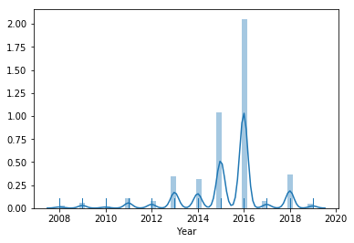

```python
sns.distplot(df.Year, rug = True)
```

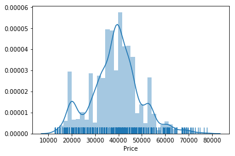

```python
sns.distplot(df.Price, rug = True)
```

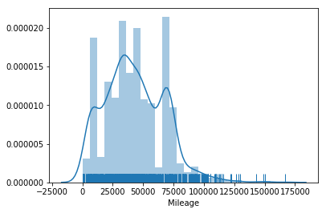

```python
sns.distplot(df.Mileage, rug = True)
```

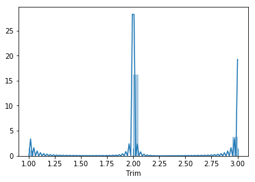

```python
sns.distplot(df.Trim, rug = True)
```

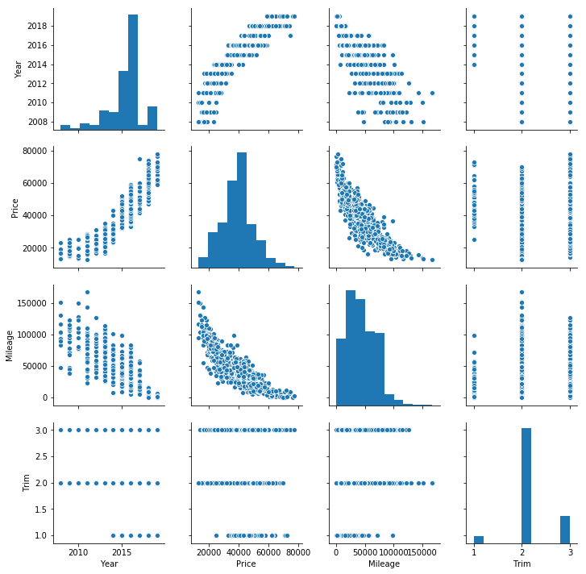

```python
sns.pairplot(df)
```

```python
#Linear regression
import sklearn as sk
from sklearn.model_selection import train_test_split
import statsmodels.formula.api as smf
import sklearn.ensemble as skens
import sklearn.metrics as skmetric
import sklearn.naive_bayes as sknb
import sklearn.tree as sktree
import sklearn.externals.six as sksix
import IPython.display as ipd
from sklearn import metrics
import os
# Filter all warnings.
import warnings
warnings.filterwarnings('ignore')
```

```python
#train test split
df_train,df_test = train_test_split(df, test_size=0.3)
```

```python
len(df_train), len(df_test), len(df)
```

```
(1285, 552, 1837)
```

```python
model1 = smf.ols('Price ~ Mileage + C(Year) + C(Trim)', data = df_train).fit()
model1.summary()
```

OLS Regression Results

| Dep. Variable: | Price | R-squared: | 0.914 |
| --- | --- | --- | --- |
| Model: | OLS | Adj. R-squared: | 0.913 |
| Method: | Least Squares | F-statistic: | 959.3 |
| Date: | Sun, 21 Apr 2019 | Prob (F-statistic): | 0.00 |
| Time: | 19:32:21 | Log-Likelihood: | -12152. |
| No. Observations: | 1285 | AIC: | 2.433e+04 |
| Df Residuals: | 1270 | BIC: | 2.441e+04 |
| Df Model: | 14 |  |  |
| Covariance Type: | nonrobust |  |  |

|  | coef | std err | t | P>\|t\| | [0.025 | 0.975] |
| --- | --- | --- | --- | --- | --- | --- |
| Intercept | 3.533e+04 | 1358.303 | 26.008 | 0.000 | 3.27e+04 | 3.8e+04 |
| C(Year)[T.2009] | -867.6216 | 1391.474 | -0.624 | 0.533 | -3597.462 | 1862.219 |
| C(Year)[T.2010] | 910.4475 | 1664.211 | 0.547 | 0.584 | -2354.457 | 4175.352 |
| C(Year)[T.2011] | -519.6469 | 1305.955 | -0.398 | 0.691 | -3081.714 | 2042.420 |
| C(Year)[T.2012] | 1629.4574 | 1353.389 | 1.204 | 0.229 | -1025.668 | 4284.582 |
| C(Year)[T.2013] | 854.7709 | 1233.590 | 0.693 | 0.488 | -1565.328 | 3274.870 |
| C(Year)[T.2014] | 6657.7436 | 1247.290 | 5.338 | 0.000 | 4210.768 | 9104.720 |
| C(Year)[T.2015] | 1.009e+04 | 1241.102 | 8.130 | 0.000 | 7655.356 | 1.25e+04 |
| C(Year)[T.2016] | 1.38e+04 | 1238.610 | 11.145 | 0.000 | 1.14e+04 | 1.62e+04 |
| C(Year)[T.2017] | 2.174e+04 | 1402.398 | 15.504 | 0.000 | 1.9e+04 | 2.45e+04 |
| C(Year)[T.2018] | 2.318e+04 | 1324.908 | 17.495 | 0.000 | 2.06e+04 | 2.58e+04 |
| C(Year)[T.2019] | 3.219e+04 | 1563.942 | 20.585 | 0.000 | 2.91e+04 | 3.53e+04 |
| C(Trim)[T.2] | -822.3476 | 408.324 | -2.014 | 0.044 | -1623.411 | -21.284 |
| C(Trim)[T.3] | 3332.9208 | 460.455 | 7.238 | 0.000 | 2429.584 | 4236.258 |
| Mileage | -0.1917 | 0.005 | -35.584 | 0.000 | -0.202 | -0.181 |

| Omnibus: | 256.376 | Durbin-Watson: | 1.952 |
| --- | --- | --- | --- |
| Prob(Omnibus): | 0.000 | Jarque-Bera (JB): | 497.794 |
| Skew: | 1.175 | Prob(JB): | 8.04e-109 |
| Kurtosis: | 4.943 | Cond. No. | 2.40e+06 |

Warnings:  
[1] Standard Errors assume that the covariance matrix of the errors is correctly specified.  
[2] The condition number is large, 2.4e+06. This might indicate that there are  
strong multicollinearity or other numerical problems.

```python
X = pd.DataFrame(df_test, columns = ['Year', 'Mileage', 'Trim'])
yp=model1.predict(X)
resid=df_test.Price - yp
rss=np.sum(abs(resid))
MAE=rss/(model1.nobs-2)
MAE
```

```
996.1251194982622
```

```python
#Here since  there are multicollinearity
```

```python
from sklearn.ensemble import RandomForestRegressor
from sklearn.datasets import make_regression
```

```python
X = pd.DataFrame(df_train, columns = ['Year', 'Mileage', 'Trim'])
y = pd.DataFrame(df_train, columns = ['Price'])
X, y = make_regression(n_features = 3)
regr = RandomForestRegressor()
regr.fit(X, y)
```

```
RandomForestRegressor(bootstrap=True, criterion='mse', max_depth=None,
           max_features='auto', max_leaf_nodes=None,
           min_impurity_decrease=0.0, min_impurity_split=None,
           min_samples_leaf=1, min_samples_split=2,
           min_weight_fraction_leaf=0.0, n_estimators=10, n_jobs=None,
           oob_score=False, random_state=None, verbose=0, warm_start=False)
```

```python
print(regr.feature_importances_)
```

```
[0.34434841 0.03716018 0.61849141]
```

```python
X_new = pd.DataFrame(df_test, columns = ['Year', 'Mileage', 'Trim'])
yp=regr.predict(X_new)
print('MSE:', metrics.mean_absolute_error(df_test.Price, yp))
```

```
MSE: 38452.944246427964
```

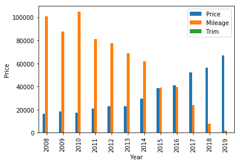

```python
rep_plot = df.groupby("Year").mean().plot(kind='bar')
rep_plot.set_xlabel("Year")
rep_plot.set_ylabel("Price")
```

As we could see above, there are two major worth-noting informations. First if we check the blue bar, there is the upward trend of price against model year, which make sence because newer cars definately worth more.

Moreover, as we check the orange bar, we could see there is a downward trend for car's mileage from 2010 to 2019, which also make sence since older cars tend to have migher mileage.

If we look close enough, we could see the price gap between 2014 to 2015 is noticeably larger than the price gap between 2013 to 2014. We need to keep in mind that facelift for this car happened in 2015. However, by just looking at this graph, we really cannot make any conclusion. We need numbers to prove our hypothesis, which is there is a significant difference of price between and after facelift.

```python
#add another column to the dataframe
df['second_Gen'] = df.apply(lambda row: row.Year >= 2015, axis=1)
df
```

|  | Year | Price | Mileage | Trim | second_Gen |
| --- | --- | --- | --- | --- | --- |
| 0 | 2016 | 36999 | 15938 | 2 | True |
| 1 | 2015 | 32998 | 39894 | 1 | True |
| 2 | 2016 | 34900 | 36176 | 2 | True |
| 3 | 2018 | 46885 | 7203 | 2 | True |
| 4 | 2019 | 61225 | 1536 | 2 | True |
| 5 | 2016 | 34999 | 23555 | 2 | True |
| 6 | 2017 | 43863 | 24560 | 2 | True |
| 7 | 2010 | 12990 | 94821 | 2 | False |
| 8 | 2015 | 32875 | 33438 | 2 | True |
| 9 | 2018 | 48400 | 5751 | 2 | True |
| 10 | 2016 | 39987 | 26541 | 2 | True |
| 11 | 2010 | 13999 | 103277 | 3 | False |
| 12 | 2016 | 33598 | 40882 | 2 | True |
| 13 | 2016 | 35000 | 31999 | 2 | True |
| 14 | 2016 | 37929 | 30325 | 2 | True |
| 15 | 2015 | 37899 | 44781 | 3 | True |
| 16 | 2016 | 32926 | 72147 | 2 | True |
| 17 | 2016 | 38981 | 44844 | 2 | True |
| 18 | 2016 | 40469 | 36374 | 2 | True |
| 19 | 2014 | 28993 | 68142 | 2 | False |
| 20 | 2013 | 19950 | 71415 | 2 | False |
| 21 | 2016 | 45995 | 8742 | 2 | True |
| 22 | 2016 | 40039 | 31676 | 2 | True |
| 23 | 2015 | 31995 | 55948 | 2 | True |
| 24 | 2018 | 52975 | 6260 | 2 | True |
| 25 | 2016 | 43994 | 19755 | 2 | True |
| 26 | 2016 | 34926 | 65764 | 2 | True |
| 27 | 2015 | 42000 | 33190 | 3 | True |
| 28 | 2015 | 37990 | 24590 | 2 | True |
| 29 | 2016 | 35984 | 52767 | 2 | True |
| ... | ... | ... | ... | ... | ... |
| 1807 | 2016 | 47995 | 16779 | 2 | True |
| 1808 | 2016 | 47995 | 19386 | 1 | True |
| 1809 | 2018 | 54991 | 15083 | 1 | True |
| 1810 | 2015 | 41991 | 38088 | 2 | True |
| 1811 | 2016 | 49703 | 21655 | 2 | True |
| 1812 | 2017 | 54888 | 12276 | 2 | True |
| 1813 | 2011 | 12799 | 166860 | 2 | False |
| 1814 | 2012 | 18999 | 92674 | 2 | False |
| 1815 | 2016 | 42981 | 31060 | 1 | True |
| 1816 | 2016 | 42981 | 33750 | 1 | True |
| 1817 | 2015 | 42995 | 53862 | 3 | True |
| 1818 | 2016 | 43995 | 48614 | 2 | True |
| 1819 | 2016 | 46788 | 30549 | 1 | True |
| 1820 | 2016 | 46995 | 33908 | 2 | True |
| 1821 | 2016 | 48700 | 30880 | 2 | True |
| 1822 | 2016 | 48981 | 31166 | 2 | True |
| 1823 | 2016 | 48987 | 33232 | 2 | True |
| 1824 | 2016 | 49908 | 30278 | 2 | True |
| 1825 | 2016 | 52897 | 37368 | 3 | True |
| 1826 | 2018 | 53981 | 9958 | 2 | True |
| 1827 | 2017 | 57499 | 16837 | 3 | True |
| 1828 | 2018 | 59981 | 8817 | 2 | True |
| 1829 | 2014 | 31770 | 43015 | 2 | False |
| 1830 | 2016 | 52800 | 18462 | 3 | True |
| 1831 | 2013 | 23700 | 94183 | 3 | False |
| 1832 | 2013 | 25598 | 80202 | 3 | False |
| 1833 | 2015 | 38995 | 48559 | 2 | True |
| 1834 | 2016 | 43950 | 40306 | 3 | True |
| 1835 | 2013 | 28700 | 88732 | 3 | False |
| 1836 | 2016 | 49243 | 50789 | 3 | True |

1837 rows × 5 columns

```python
#use ANOVA TEST
model3 = smf.ols('Price ~ C(second_Gen)', data = df).fit()
model3.summary()
```

OLS Regression Results

| Dep. Variable: | Price | R-squared: | 0.506 |
| --- | --- | --- | --- |
| Model: | OLS | Adj. R-squared: | 0.506 |
| Method: | Least Squares | F-statistic: | 1882. |
| Date: | Sun, 21 Apr 2019 | Prob (F-statistic): | 1.40e-283 |
| Time: | 19:32:21 | Log-Likelihood: | -18959. |
| No. Observations: | 1837 | AIC: | 3.792e+04 |
| Df Residuals: | 1835 | BIC: | 3.793e+04 |
| Df Model: | 1 |  |  |
| Covariance Type: | nonrobust |  |  |

|  | coef | std err | t | P>\|t\| | [0.025 | 0.975] |
| --- | --- | --- | --- | --- | --- | --- |
| Intercept | 2.438e+04 | 374.104 | 65.156 | 0.000 | 2.36e+04 | 2.51e+04 |
| C(second_Gen)[T.True] | 1.826e+04 | 420.933 | 43.383 | 0.000 | 1.74e+04 | 1.91e+04 |

| Omnibus: | 358.550 | Durbin-Watson: | 1.067 |
| --- | --- | --- | --- |
| Prob(Omnibus): | 0.000 | Jarque-Bera (JB): | 703.716 |
| Skew: | 1.158 | Prob(JB): | 1.55e-153 |
| Kurtosis: | 4.958 | Cond. No. | 4.15 |

Warnings:  
[1] Standard Errors assume that the covariance matrix of the errors is correctly specified.

```python
aov_table = sm.stats.anova_lm(model3, typ = 2)
print(aov_table)
```

```
                     sum_sq      df            F         PR(>F)
C(second_Gen)  1.016720e+11     1.0  1882.043693  1.403947e-283
Residual       9.913064e+10  1835.0          NaN            NaN
```

As we could observe from ANOVA table, the p-value is very small (smaller than 0.01), therefore, we will reject the null hypothesis, which is there is no significant difference for used car price based on first generation and second generation. And we come up with the conclusion that facelift DO have a crucial effect on a used car's price.